# Statistical Analysis

```r
library(MASS)
library(pscl)
library(cplm)
library(tweedie)
library(broom)
library("tidyverse")
library(devtools)
install_github('legendenomgeorg/VitalDBR/VitalDBR')
library(VitalDBR)
library(MuMIn)
#head(data)
```

## Motivation for statistical analysis:

As stated in the introduction, we want to look into the importance of the Pulse Pressure Variation (PPV) on the amount of days the patient spend in the ICU (intensive care unit).

The independent variables we choose to do this study are the following:

- Age
  - The age of the patient
- Sex
  - The gender of the patient
- Asa
  - ASA score is a metric used to determine if someone is healhy enough to tolerate surgery and anasthesia
- Emop
  - A binary variable that is 1 if the operation is an emergency.
- BMI
  - The body mass index of the patient. Calculated as weight over heigh in meters squared: $BMI = (\frac{kg}{m^2}$
- PPV_under_5
  - Proportion of 2 minute intervals with a pulse pressure variation under 5 out of the entire operation
- PPV_over_8
  - Proportion of 2 minute intervals with a pulse pressure variation over 8 out of the entire operation
- PPV_avg_first30
  - The average of the first 15 two minute interval measurements of PPV
- PPV_avg_last30
  - The average of the last 15 two minute interval measurements of PPV
  - Note due to anomalies in data, some of these values are 0, and we have therefore removed those cases from our data.
- preop_htn
  - A measurement of how healthy the patients kidneys are
- preop_dm
  - Whether the patient has too high blood pressure
- preop_cr
  - A measurement of how healthy the patients kidneys are
- preop_alt
  - A measurement of how healthy the patients kidneys are
- knife_time
  - Total time of the operation, in hours
  - Derived from the opstart and opend columns
- dangerop
  - Indicates whether the operation is of a type deemed generally dangerous. Which are:
  - Colorectal, Hepatic, Vascular, Biliary/pancreas, stomach and Transplantation
  - Note that this is very broad, but it is our best way atm, to get an indicator of the severity of the operation

## Analysis

First we import the data created by the algorithm above, but we exclude the parameters we don’t need, like index, caseid, death in hospital, anasthesia start and end.

```r
 data <- read.csv("../Investigationsdf30.csv")
cases <- VitalDBR::load_VDB("https://api.vitaldb.net/cases")
cases <- cases %>% select('caseid', 'aneend', 'anestart', 'preop_htn', 'preop_dm', 'preop_ecg', 'preop_pft', 'preop_cr', 'preop_alt', 'optype')
merged <- merge(x=data,y=cases,by="caseid")
merged$knife_time <- (merged$opend - merged$opstart) / 3600
data <- merged %>% select(-'X', -'aneend', -'anestart', -'opend', -'opstart') %>% filter(preop_ecg == "Normal Sinus Rhythm")
data <- mutate_if(data, is.character, as.factor) %>% select(-'caseid', -'death_inhosp', -'preop_ecg')
data$sex <- ifelse(data$sex=='M', 1,0)
data$preop_pft <- ifelse(data$preop_pft=='Normal',1, 0)
data$knife_time <- round(data$knife_time, 2)
data$ppv_over8 <- round(data$ppv_over8, 4)
data$ppv_avg_first30 <- round(data$ppv_avg_first30, 4)
data$ppv_avg_last_30 <- round(data$ppv_avg_last_30, 4)
data$age <- as.integer(data$age)
#
data$dangerop <- ifelse(data$optype %in% c("Breast", "Thyroid", "Others"),0,1)
data <- select(data, -"optype")


#####Hopefully we can remove this with the new data
data <- data[!(data$ppv_avg_last_30==0),]
#####

data <- na.omit(data)
icu <- data$icu_days
```

## Linear Regression

First of all we want to set a baseline for our future models, we do this with a linear regression:

```r
summary(linear_model <-lm(icu_days ~ . , data=data))
```

```
##
## Call:
## lm(formula = icu_days ~ ., data = data)
##
## Residuals:
##     Min      1Q  Median      3Q     Max
## -18.396  -1.347  -0.254   0.795  71.155
##
## Coefficients:
##                   Estimate Std. Error t value Pr(>|t|)
## (Intercept)     -1.9272979  1.1276408  -1.709   0.0877 .
## age             -0.0443182  0.0077351  -5.730 1.27e-08 ***
## sex             -0.1640799  0.2300804  -0.713   0.4759
## asa              1.9872708  0.1774806  11.197  < 2e-16 ***
## emop             1.7417999  0.2864140   6.081 1.60e-09 ***
## bmi              0.0098046  0.0296180   0.331   0.7407
## ppv_under5       0.0834803  0.8127939   0.103   0.9182
## ppv_over8        0.7557475  0.9254828   0.817   0.4143
## ppv_avg_first30 -0.0096578  0.0090444  -1.068   0.2858
## ppv_avg_last_30  0.0135603  0.0093321   1.453   0.1465
## preop_htn        0.0640203  0.2535129   0.253   0.8007
## preop_dm        -0.4118629  0.3186152  -1.293   0.1964
## preop_pft        0.0283370  0.2653337   0.107   0.9150
## preop_cr        -0.2481457  0.0477143  -5.201 2.34e-07 ***
## preop_alt        0.0076178  0.0005919  12.869  < 2e-16 ***
## knife_time       0.3771995  0.0622296   6.061 1.81e-09 ***
## dangerop        -0.5568722  0.2781712  -2.002   0.0455 *
## ---
## Signif. codes:  0 '***' 0.001 '**' 0.01 '*' 0.05 '.' 0.1 ' ' 1
##
## Residual standard error: 3.772 on 1192 degrees of freedom
## Multiple R-squared:  0.3518, Adjusted R-squared:  0.3431
## F-statistic: 40.44 on 16 and 1192 DF,  p-value: < 2.2e-16
```

We will refrain from interpreting coefficients, before we have decided on the best model. So to determine whether our linear regression model violates its assumptions, we do a classic plot of the residuals against the dependent variable and a qqplot.

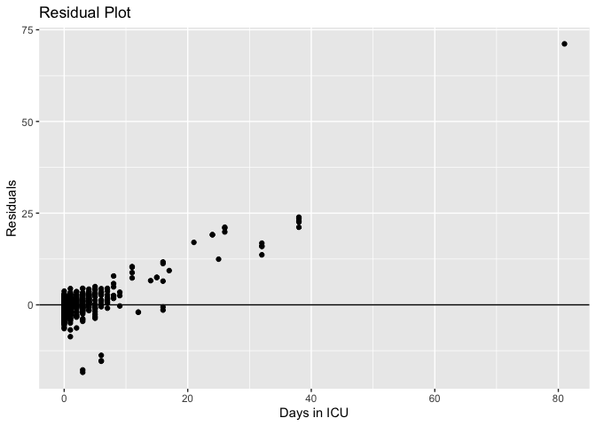

```r
residualplot<- ggplot(broom::augment(linear_model), aes(x = icu_days, y = .resid)) + geom_point() +geom_hline(yintercept=0) +xlab("Days in ICU") + ylab("Residuals") + ggtitle("Residual Plot")

qqplot <- ggplot(broom::augment(linear_model), aes(sample = .resid)) +
  geom_qq() + geom_qq_line() + xlab("Theoretical Quantiles") + ylab("Residuals") + ggtitle("Normal QQ-plot")
#Skal kombineres man kan ikke få lov til at knitte når jeg gør det
residualplot
```

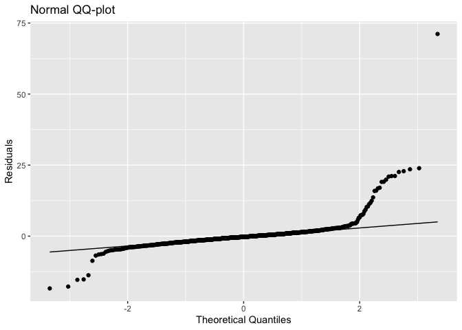

```r
qqplot
```

On the left plot where we plot the residuals against our dependent variable, we can see that there seems to be systematic deviation from the baseline, indicating a non-linear relationship in our data. It also indicates heteroskedasticity*, since the variance seems to be dependent on days in ICU. We can also see that both ends of our qqplot is behaving unexpectedly, this indicates that the errors are not normally distributed. Which breaks the assumption that errors given X are normally distributed. This does not invalidate our regression coefficients, but prevents us from using tests like ANOVA, that assume normal errors.*

As our data breaks various assumptions, we will not consider the linear regression in our future comparissons, as it is not a valid model.

Let’s inspect our dependent variable then.

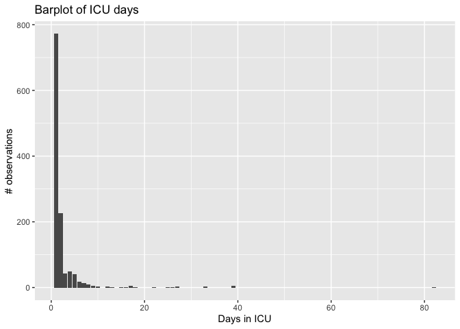

```r
count <- table(factor(icu, levels = 0:81))

icu_barplot<-ggplot(data=as.data.frame(count), aes(x=as.integer(Var1), y=Freq)) +
  geom_bar(stat="identity") +
  ggtitle("Barplot of ICU days")+
  xlab("Days in ICU") + ylab("# observations")
icu_barplot
```

We see that it doesn’t follow a normal distribution and that it seems to follow a sort of poisson distribution, which also makes intuitive sense due to the nature of time spent in the ICU. But taking a closer look, we see that there are way too many 0-observations for it to be a simple poisson distribution.

```r
sum(data$icu_days==0)/sum(nrow(data))
```

```
## [1] 0.6385443
```

## What is a Generalized Linear Model?

A standard linear regression fits a model of the form
$$Y = X\beta + \epsilon$$
where $\epsilon \sim N(0,\sigma^2)$. We checked above that our regression does not live up to the requirement for $\epsilon$. If we subtract the $\epsilon$ on both sides we can write the regression as
$$E[Y|X] =\beta X$$
We can then apply a link function g() to the expected value of Y given X
$$g(E[Y|X]) = \beta X$$
The link function converts the expected value of our dependent variable to a linear scale. This means we can formulate the GLM as:
$$E[Y|X] = g^{-1}(\beta X )$$
When using GLM’s in r, we choose the “family”, which decides the link function $g()$ and the appropriate distribution of the errors. When choosing “poisson” as our family, we choose the log function which ensures that as our link function is the “log” function, that our errors are distributed with the poisson distribution. A standard linear regression is actually just a GLM with the “gaussian family” ie. errors normally distributed and the identity function as the link function! Best illustrated with the formula we know as:
$$Y \sim N(\beta X, \sigma^2)$$
Where the mean is $\mu$ is given by $E[Y|X] = g^{-1}(\beta X)$ where $g(x) = x$ ie. the identity function.

Similarly we can write our poisson GLM in this fashion: When we introduce the log link function to the formula above it becomes
$$log(E(Y|X)) = \beta X$$
$$E[Y|X] = e^{\beta X}$$
And when we reintroduce the poisson error term, we get our final model:
$$Y \sim Poisson( e^{\beta X} )$$
This is the model we will try now.

## GLM

### Poisson GLM

Even though we probably have too many zeros as we saw earlier, we will still try to use a simple poisson model for our regression:

```r
summary(pois_reg <- glm(icu_days ~ ., data = data, family='poisson'(link="log")))
```

```
##
## Call:
## glm(formula = icu_days ~ ., family = poisson(link = "log"), data = data)
##
## Deviance Residuals:
##     Min       1Q   Median       3Q      Max
## -7.8383  -1.1044  -0.7994   0.2269  12.5794
##
## Coefficients:
##                   Estimate Std. Error z value Pr(>|z|)
## (Intercept)     -1.902e+00  2.508e-01  -7.586 3.31e-14 ***
## age             -1.143e-02  1.430e-03  -7.995 1.29e-15 ***
## sex              1.946e-01  5.844e-02   3.330 0.000867 ***
## asa              8.508e-01  3.159e-02  26.930  < 2e-16 ***
## emop             1.039e+00  5.904e-02  17.601  < 2e-16 ***
## bmi              1.755e-02  6.534e-03   2.685 0.007246 **
## ppv_under5      -7.105e-01  1.838e-01  -3.866 0.000111 ***
## ppv_over8       -3.864e-01  2.040e-01  -1.894 0.058245 .
## ppv_avg_first30 -1.486e-02  3.946e-03  -3.766 0.000166 ***
## ppv_avg_last_30  8.950e-03  1.760e-03   5.086 3.66e-07 ***
## preop_htn        1.100e-01  6.354e-02   1.732 0.083309 .
## preop_dm        -2.263e-01  8.390e-02  -2.697 0.006993 **
## preop_pft       -1.200e-02  6.146e-02  -0.195 0.845215
## preop_cr        -8.253e-02  1.351e-02  -6.108 1.01e-09 ***
## preop_alt        7.628e-04  5.389e-05  14.154  < 2e-16 ***
## knife_time       1.897e-01  1.026e-02  18.494  < 2e-16 ***
## dangerop        -5.044e-01  6.340e-02  -7.957 1.76e-15 ***
## ---
## Signif. codes:  0 '***' 0.001 '**' 0.01 '*' 0.05 '.' 0.1 ' ' 1
##
## (Dispersion parameter for poisson family taken to be 1)
##
##     Null deviance: 6036.4  on 1208  degrees of freedom
## Residual deviance: 2671.2  on 1192  degrees of freedom
## AIC: 3878.3
##
## Number of Fisher Scoring iterations: 6
```

We see a lot of significant coefficients in this summary, but before we can interpret them, we need to know whether our model breaks any assumptions.

If we do some further investigation, we can also observe that the mean is not equal to the variance:

```r
mean(icu)
```

```
## [1] 1.404467
```

```r
var(icu)
```

```
## [1] 21.65664
```

This violates the properties of the poisson distribution, where
$$E(X) = VAR(X) = \lambda, \ \ X \sim poisson(\lambda)$$
When the variance is larger than the mean, we are working with as so-called “over-dispersed” model, which further incentivises us to look into more advanced modelling.

### Overdispersement

We can test for overdispersement by dividing the residual deviance with the number of degrees of freedom, if the model is appropriately dispersed it should equal 1.

```r
pois_reg$deviance/pois_reg$df.residual
```

```
## [1] 2.240964
```

As we can see our model is clearly overdispersed

The reason why we don’t want overdispersion, is that when the model is overdispersed, we underestimate standard errors of the coefficients, and when we underestimate those, we get too optimistic p-values. This fits well with the coefficient summary above, where almost all coefficients are highly significant (https://stats.stackexchange.com/questions/459864/overdispersion-in-fitted-generalized-linear-model-with-insignificant-regression)

This means that we will not regard the simple poisson regression as valid, and therefore not include it in the coming comparison between models.

Instead we will now try with the negative binomial distribution.

### Negative binomial GLM

If Y is distributed with the negative binomial distribution, it can be written as:
$$Y \sim NB(r,p)$$
where r is the number of failures until the experiment is stopped and p is the probability of success. This is the normal formulation of the distribution, but the distribution can also be formulated as a poisson distribution with an added Gamma noise variable $r$ which has mean 1 and a scale parameter $v$. This means that we can formulate the Negative Binomial distribution in terms of it’s mean and a dispersement variable $r$
$$Y \sim NB(\mu, \alpha) = \frac{\Gamma(r+k)}{k ! \Gamma(r)}\left(\frac{r}{r+\mu}\right)^{r}\left(\frac{\mu}{r+\mu}\right)^{k}$$
This in itself is not that interesting, but now the distribution is defined from it’s mean, and because the GLM models the mean of a regression this allows us to use the negative binomial distribution as our family.

Now, when fitting the negative binomial we can express it in terms of its mean through a log link and $r$ , which means that the formula for the regression mean becomes:
$$Y \sim NB(e^{\beta X}, r)$$
Running the regression in R gives us the following result:

```r
nbin_reg <- MASS::glm.nb(icu_days ~ . , data=data)
summary(nbin_reg)
```

```
##
## Call:
## MASS::glm.nb(formula = icu_days ~ ., data = data, init.theta = 0.6869850102,
##     link = log)
##
## Deviance Residuals:
##     Min       1Q   Median       3Q      Max
## -2.0775  -0.8333  -0.5910  -0.0109   3.8987
##
## Coefficients:
##                   Estimate Std. Error z value Pr(>|z|)
## (Intercept)     -3.2144307  0.5369299  -5.987 2.14e-09 ***
## age             -0.0088448  0.0034564  -2.559  0.01050 *
## sex              0.1726304  0.1103521   1.564  0.11773
## asa              0.9881788  0.0813178  12.152  < 2e-16 ***
## emop             1.2611747  0.1204820  10.468  < 2e-16 ***
## bmi              0.0055618  0.0138619   0.401  0.68825
## ppv_under5      -0.2527478  0.3812566  -0.663  0.50737
## ppv_over8       -0.2681819  0.4455979  -0.602  0.54728
## ppv_avg_first30 -0.0201474  0.0074695  -2.697  0.00699 **
## ppv_avg_last_30  0.0065360  0.0043901   1.489  0.13654
## preop_htn        0.0330161  0.1191010   0.277  0.78162
## preop_dm        -0.0467848  0.1474827  -0.317  0.75107
## preop_pft       -0.1176328  0.1213299  -0.970  0.33228
## preop_cr        -0.0636286  0.0220009  -2.892  0.00383 **
## preop_alt        0.0009948  0.0001986   5.009 5.48e-07 ***
## knife_time       0.3406440  0.0277703  12.266  < 2e-16 ***
## dangerop        -0.1939827  0.1368577  -1.417  0.15636
## ---
## Signif. codes:  0 '***' 0.001 '**' 0.01 '*' 0.05 '.' 0.1 ' ' 1
##
## (Dispersion parameter for Negative Binomial(0.687) family taken to be 1)
##
##     Null deviance: 1817.71  on 1208  degrees of freedom
## Residual deviance:  916.87  on 1192  degrees of freedom
## AIC: 2838
##
## Number of Fisher Scoring iterations: 1
##
##
##               Theta:  0.6870
##           Std. Err.:  0.0636
##
##  2 x log-likelihood:  -2802.0060
```

As this model does not break any assumptions, we will use this as our baseline for future models, but we will wait with the interpretation until the end.

But what if our problem is not overdispersement, but actually zero inflation? Meaning that the difference between mean and variance in our data is actually caused by the high amount of 0’s, and that if we account for those, the poisson model might not be overdispersed at all.

##Zero Inflated models

### Zero Inflated Poisson

Looking at the zero-inflated Poisson distribution, we can see that this model is comprised of two different processes. The first of which generates zeros:
$$\operatorname{Pr}(Y=0)=\pi+(1-\pi) e^{-\lambda}$$
Which is a binomial GLM, that predicts the odds of seeing an event given a vector of regression variables. Essentially a logit regression, as it predicts a “probability” between 0 and 1 of observing 0.

These ideas are then transformed to a GLM, like we’ve shown above, and can then be modelled in r with the “zeroinfl” package. There are various formulations we can use, depending on how we believe the variables influence each part of the model. For example we can write the formula as:

```r
pscl::zeroinfl(icu_days ~ . , data=data, dist="poisson")
```

```
##
## Call:
## pscl::zeroinfl(formula = icu_days ~ ., data = data, dist = "poisson")
##
## Count model coefficients (poisson with log link):
##     (Intercept)              age              sex              asa
##      -0.1968471       -0.0128205        0.1617678        0.6135847
##            emop              bmi       ppv_under5        ppv_over8
##       0.6083556        0.0230334       -0.6831881       -0.4287908
## ppv_avg_first30  ppv_avg_last_30        preop_htn         preop_dm
##      -0.0077881        0.0067608        0.1849055       -0.2204888
##       preop_pft         preop_cr        preop_alt       knife_time
##       0.0134653       -0.1190273        0.0005555        0.1247864
##        dangerop
##      -0.6152869
##
## Zero-inflation model coefficients (binomial with logit link):
##     (Intercept)              age              sex              asa
##        4.778219        -0.017045        -0.016443        -0.778725
##            emop              bmi       ppv_under5        ppv_over8
##       -1.219187         0.025982        -0.159071         0.459558
## ppv_avg_first30  ppv_avg_last_30        preop_htn         preop_dm
##        0.013798        -0.001807         0.416972        -0.331854
##       preop_pft         preop_cr        preop_alt       knife_time
##        0.168678        -0.156054        -0.003967        -0.565130
##        dangerop
##       -0.343631
```

If we believe that all the variables both influence the zero inflation AND the poisson distribution

Or we can do:

```r
pscl::zeroinfl(icu_days ~ .| 1 , data=data, dist="poisson")
```

```
##
## Call:
## pscl::zeroinfl(formula = icu_days ~ . | 1, data = data, dist = "poisson")
##
## Count model coefficients (poisson with log link):
##     (Intercept)              age              sex              asa
##      -0.6566056       -0.0132476        0.2150974        0.6664588
##            emop              bmi       ppv_under5        ppv_over8
##       0.8117777        0.0245248       -0.8074371       -0.4139736
## ppv_avg_first30  ppv_avg_last_30        preop_htn         preop_dm
##      -0.0167580        0.0072855        0.1860388       -0.2002526
##       preop_pft         preop_cr        preop_alt       knife_time
##      -0.0229631       -0.0704738        0.0005811        0.1584288
##        dangerop
##      -0.6091842
##
## Zero-inflation model coefficients (binomial with logit link):
## (Intercept)
##     -0.1994
```

if we believe that the variables have no effect on the zero inflation. ie. there are a part of the zero observations that are just inherently there or decided by a variable we do not have access to.

But we will use this model:

```r
summary(zi_pois_reg <-pscl::zeroinfl(icu_days ~ .| . -ppv_under5 -ppv_over8 -ppv_avg_last_30 , data=data, dist="poisson"))
```

```
##
## Call:
## pscl::zeroinfl(formula = icu_days ~ . | . - ppv_under5 - ppv_over8 -
##     ppv_avg_last_30, data = data, dist = "poisson")
##
## Pearson residuals:
##       Min        1Q    Median        3Q       Max
## -3.764742 -0.549385 -0.313497  0.003109 15.803127
##
## Count model coefficients (poisson with log link):
##                   Estimate Std. Error z value Pr(>|z|)
## (Intercept)     -1.929e-01  2.743e-01  -0.703 0.481895
## age             -1.278e-02  1.546e-03  -8.270  < 2e-16 ***
## sex              1.583e-01  6.698e-02   2.364 0.018089 *
## asa              6.133e-01  3.758e-02  16.319  < 2e-16 ***
## emop             6.140e-01  7.553e-02   8.128 4.35e-16 ***
## bmi              2.298e-02  6.878e-03   3.341 0.000834 ***
## ppv_under5      -6.743e-01  1.967e-01  -3.428 0.000609 ***
## ppv_over8       -4.642e-01  2.205e-01  -2.105 0.035269 *
## ppv_avg_first30 -7.120e-03  5.059e-03  -1.407 0.159339
## ppv_avg_last_30  6.879e-03  1.690e-03   4.070 4.69e-05 ***
## preop_htn        1.855e-01  7.226e-02   2.568 0.010237 *
## preop_dm        -2.154e-01  1.003e-01  -2.148 0.031720 *
## preop_pft        1.736e-02  6.864e-02   0.253 0.800307
## preop_cr        -1.259e-01  2.446e-02  -5.148 2.63e-07 ***
## preop_alt        5.561e-04  3.754e-05  14.816  < 2e-16 ***
## knife_time       1.253e-01  1.263e-02   9.924  < 2e-16 ***
## dangerop        -6.198e-01  7.615e-02  -8.139 3.99e-16 ***
##
## Zero-inflation model coefficients (binomial with logit link):
##                  Estimate Std. Error z value Pr(>|z|)
## (Intercept)      4.822414   0.848043   5.687 1.30e-08 ***
## age             -0.017132   0.006364  -2.692   0.0071 **
## sex             -0.039848   0.196306  -0.203   0.8391
## asa             -0.797478   0.161262  -4.945 7.60e-07 ***
## emop            -1.199460   0.252236  -4.755 1.98e-06 ***
## bmi              0.025886   0.023054   1.123   0.2615
## ppv_avg_first30  0.020746   0.011954   1.736   0.0826 .
## preop_htn        0.412120   0.217045   1.899   0.0576 .
## preop_dm        -0.307475   0.283118  -1.086   0.2775
## preop_pft        0.181093   0.216737   0.836   0.4034
## preop_cr        -0.194996   0.123454  -1.580   0.1142
## preop_alt       -0.003806   0.001774  -2.145   0.0319 *
## knife_time      -0.556601   0.062857  -8.855  < 2e-16 ***
## dangerop        -0.367700   0.224530  -1.638   0.1015
## ---
## Signif. codes:  0 '***' 0.001 '**' 0.01 '*' 0.05 '.' 0.1 ' ' 1
##
## Number of iterations in BFGS optimization: 40
## Log-likelihood: -1636 on 31 Df
```

As we think that only a specific set of variables influences the zero inflation. In this case we first of all believe that emergency operations influence whether people are designated to spent 0 days in the ICU. The reason is that an operation being an emergency, will probably have an influence on whether the patient spent 0 days in the ICU. With a simple tally, we can see that people undergoing non emergency operations generally spend 0 days in the ICU

```r
# Number of non Emergency operations with 0 days spoent in the ICU
data %>% filter(emop==0, icu_days==0) %>% nrow()
```

```
## [1] 663
```

```r
# Number of Emergency operations with 0 days spoent in the ICU
data %>% filter(emop==1, icu_days==0) %>% nrow()
```

```
## [1] 109
```

We also add “dangerop” with the same argumentation.

```r
# Number of non Emergency operations with 0 days spoent in the ICU
data %>% filter(dangerop==0, icu_days==0) %>% nrow()
```

```
## [1] 208
```

```r
# Number of Emergency operations with 0 days spoent in the ICU
data %>% filter(dangerop==1, icu_days==0) %>% nrow()
```

```
## [1] 564
```

Second of all we add all variables that indicate something about the condition of the patient before the operation. Note we include PPV_avg_first30, as an indication of the patients pulse pressure before the operation.

### Zero inflated negative binomial

But actually we might be suffering from both zero-inflation AND overdispersement in the non zero observations? This calls for the zero inflated negative binomial model. This model accounts for zero-inflation, but it also has a shape better suited for overdispersed data due to the overdispersement parameter mentioned eralier.

```r
zi_nbin_reg <- pscl::zeroinfl(icu_days ~ .| . -ppv_under5 -ppv_over8 -ppv_avg_last_30, data=data, dist="negbin")
summary(zi_nbin_reg)
```

```
##
## Call:
## pscl::zeroinfl(formula = icu_days ~ . | . - ppv_under5 - ppv_over8 -
##     ppv_avg_last_30, data = data, dist = "negbin")
##
## Pearson residuals:
##       Min        1Q    Median        3Q       Max
## -1.017354 -0.499003 -0.239813 -0.007066  9.883211
##
## Count model coefficients (negbin with log link):
##                   Estimate Std. Error z value Pr(>|z|)
## (Intercept)     -1.0445792  0.5723598  -1.825 0.067995 .
## age             -0.0107073  0.0031752  -3.372 0.000746 ***
## sex              0.1319345  0.1171413   1.126 0.260045
## asa              0.7283384  0.0885459   8.226  < 2e-16 ***
## emop             0.7779357  0.1384215   5.620 1.91e-08 ***
## bmi              0.0115972  0.0139634   0.831 0.406233
## ppv_under5      -0.3828535  0.3677714  -1.041 0.297871
## ppv_over8       -0.4610227  0.4445483  -1.037 0.299709
## ppv_avg_first30 -0.0113074  0.0079955  -1.414 0.157295
## ppv_avg_last_30  0.0087845  0.0043710   2.010 0.044462 *
## preop_htn        0.0835665  0.1240494   0.674 0.500531
## preop_dm        -0.2035432  0.1614424  -1.261 0.207388
## preop_pft       -0.0556190  0.1247625  -0.446 0.655743
## preop_cr        -0.1219595  0.0225197  -5.416 6.11e-08 ***
## preop_alt        0.0008206  0.0001849   4.439 9.06e-06 ***
## knife_time       0.1379827  0.0313840   4.397 1.10e-05 ***
## dangerop        -0.3112701  0.1650836  -1.886 0.059358 .
## Log(theta)       0.1462343  0.1210108   1.208 0.226878
##
## Zero-inflation model coefficients (binomial with logit link):
##                   Estimate Std. Error z value Pr(>|z|)
## (Intercept)      7.6298667  1.6509078   4.622 3.81e-06 ***
## age             -0.0204402  0.0102373  -1.997 0.045865 *
## sex              0.1666757  0.3426615   0.486 0.626673
## asa             -1.1406999  0.3068141  -3.718 0.000201 ***
## emop            -1.6248941  0.4947316  -3.284 0.001022 **
## bmi              0.0006726  0.0414790   0.016 0.987062
## ppv_avg_first30  0.0256973  0.0232711   1.104 0.269482
## preop_htn        0.6053462  0.3906013   1.550 0.121194
## preop_dm        -0.4961445  0.5621740  -0.883 0.377482
## preop_pft        0.1518758  0.3817617   0.398 0.690756
## preop_cr        -1.3065247  0.4531367  -2.883 0.003935 **
## preop_alt       -0.0062520  0.0051044  -1.225 0.220640
## knife_time      -1.0845510  0.1505038  -7.206 5.76e-13 ***
## dangerop         0.0513020  0.4144959   0.124 0.901498
## ---
## Signif. codes:  0 '***' 0.001 '**' 0.01 '*' 0.05 '.' 0.1 ' ' 1
##
## Theta = 1.1575
## Number of iterations in BFGS optimization: 46
## Log-likelihood: -1350 on 32 Df
```

Now we have tried normal GLM and zeroinflated GLM, but before we compare the models and interpret the results, we will lastly explore the “Compound Poisson Regression.

## Compound poisson regression

The compound poisson regression is an even more advanced way of modelling our data. This distribution is useful in situations with a very large proportion of zero observations. It is commonly used in rainfall modelling , where there are many more days per year without rain than days with rain (Probably not that useful in Denmark…). It is also often used in actuarial math, especially when modelling premiums, as most people in a given year do not get any payments from their insurance, but a few people get a lot of money paid out.

Our compound distribution, often referred to as the “Compound Poisson-Gamma distribution” is defined as:
$$Y = \sum_i^T X_i$$
Where
$$T \sim Pois(\lambda), X_{i} \stackrel{\mathrm{iid}}{\sim} \operatorname{Gamma}(\alpha, \beta), \ \ T \perp X_{i}$$
Where $\perp$ means independence between two random variables.

In our case, this formula can be interpreted with an example. Let’s say we are looking at the influence of our independent variables on patients spending 29 days in the ICU ($Y=29$). Then this is comprised of two different stochastic variables. T which determines the number (count) of patients who spend 29 days in the ICU. In our case, the number of patients is given by the poisson distribution. And the other parameter X determines the chance of experiencing an event where you have to stay 29 days at the ICU, ie. the severity, which is given by the gamma distribution.

To visualize this, lets look at the barplot from the beginning, but now imagine that the vertical value is decided by a poisson distribution and the horizontal value is given by the gamma distribution. Then the compound poisson process is obtained by marginalizing over T (keeping T fixed and evaluating X).

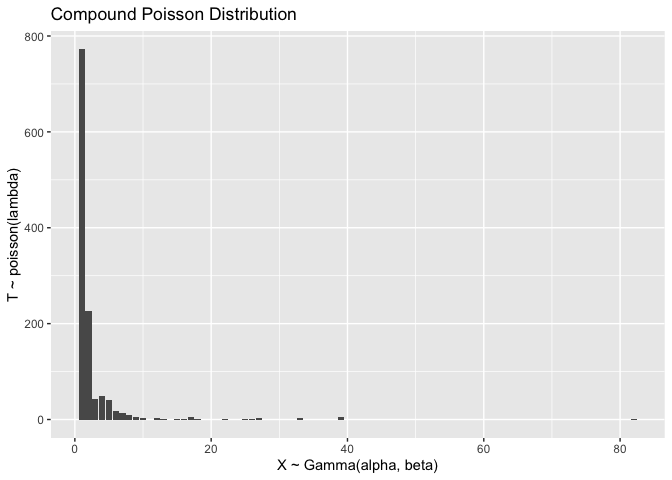

```r
icu_barplot + ggtitle("Compound Poisson Distribution") + xlab("X ~ Gamma(alpha, beta)") + ylab("T ~ poisson(lambda)")
```

To clarify, the amount of gamma distributions, depends in itself on the poisson distribution. When the poisson distribution, T, comes out to zero, then there are no gamma distributions in the sum above. which is the reason why this distribution is so powerful! When $T=0$ then $Y=0$, which allows the distribution to have a defined probability mass function at it’s origin. This is in contrast with the zero inflated model, where p(X=0) is not clearly defined.

This means that we can model our dependent variable as:
$$Y \sim CPois(\mu_i, \phi, \rho)$$
Where the parameters are defined as so:

- $\mu = E(Y)$ is the mean.
- $\phi$ is the dispersion parameter which, crudely said, indicates whether the distribution is wide or narrow
- $\rho$ is the “index parameter” and indicates which distribution from the Tweedie family we are looking at. As indicated here: https://en.wikipedia.org/wiki/Tweedie_distribution under “related distributions”, the index parameter should lie in $1 < \rho < 2$, if we are working with a compound poisson-gamma distribution.

In this form the expected value and variance is given by:
$$E[Y] = \mu$$
$$Var[Y] = \phi \cdot \mu^\rho$$
As seen previously, we can link the mean to the linear predictors through the log function. And we can finally write it in the same fashion as the two previous GLMs
$$Y \sim CPois(e^{X\beta}, \phi, \rho)$$

We can finally do this compound poisson regression using the library “cplm”

```r
c_pois_reg <- cplm::cpglm(icu_days ~ . , data = data, link = "log")
summary(c_pois_reg)
```

```
##
## Call:
## cplm::cpglm(formula = icu_days ~ ., link = "log", data = data)
##
## Deviance Residuals:
##    Min      1Q  Median      3Q     Max
## -5.763  -1.326  -1.031   0.148   8.154
##                   Estimate Std. Error t value Pr(>|t|)
## (Intercept)     -2.3932881  0.5056803  -4.733 2.48e-06 ***
## age             -0.0097001  0.0029923  -3.242  0.00122 **
## sex              0.1932774  0.1106792   1.746  0.08102 .
## asa              0.9232616  0.0674309  13.692  < 2e-16 ***
## emop             1.0859994  0.1151212   9.434  < 2e-16 ***
## bmi              0.0120380  0.0132472   0.909  0.36368
## ppv_under5      -0.5951183  0.3685721  -1.615  0.10665
## ppv_over8       -0.3570318  0.4203748  -0.849  0.39587
## ppv_avg_first30 -0.0184214  0.0073595  -2.503  0.01245 *
## ppv_avg_last_30  0.0080347  0.0038893   2.066  0.03906 *
## preop_htn        0.0859796  0.1206280   0.713  0.47613
## preop_dm        -0.1630784  0.1533378  -1.064  0.28776
## preop_pft       -0.0456616  0.1186251  -0.385  0.70036
## preop_cr        -0.0732406  0.0235577  -3.109  0.00192 **
## preop_alt        0.0007940  0.0001264   6.281 4.70e-10 ***
## knife_time       0.2334675  0.0219738  10.625  < 2e-16 ***
## dangerop        -0.3867673  0.1285536  -3.009  0.00268 **
## ---
## Signif. codes:  0 '***' 0.001 '**' 0.01 '*' 0.05 '.' 0.1 ' ' 1
##
## Estimated dispersion parameter: 2.5275
## Estimated index parameter: 1.2816
##
## Residual deviance: 2646.9  on 1192  degrees of freedom
## AIC:  3014.2
##
## Number of Fisher Scoring iterations:  6
```

## Comparing all models

### Comparing models through metrics:

We will compare our models with the metrics AICc and BIC. We look for the model with the lowest of these values.

#### AIC

AIC is defined as:
$$AIC = 2k - 2log(LL)$$
Where k is the amount of parameters in our model and LL is the log-likelihood estimate. We can break AIC into two parts. First, when the $2k$ part penalizes when we add more parameters to our model ie. it penalizes complexity and $-2log(LL)$ decreases as our model gets better at explaining our data, this rewards us for building models that fit our data well.

In this analysis we are using AICc which is a different formulation that corrects for small samples. As the number of sample goes to infinity, AICc converges to AIC, so there is no reason not to use AIC, especially since we do not have extremely many samples.

#### BIC

BIC is the Bayesian information criteria, and its formula is pretty similar to AIC’s:
$$BIC = klog(n)-2log(LL)$$
The concept is the same, but our model is not only penalized by the amount of parameters in the model, $k$, but also by the amount of data in our model $n$.

### Calculating metrics

Calculating AICc and BIC for the Compound poisson regression has to be done manually:

```r
# Calculating BIC for compound poisson glm
logLik_tweedie <-
  function(cpglm_obj) {
    # compute the density with the optimal parameters and the model coefficients
    dens <- tweedie::dtweedie(y = cpglm_obj$y,
                              mu = cpglm_obj$fitted.values,
                              xi = cpglm_obj$p,
                              phi = cpglm_obj$phi)
    # we add 2 to the number of parameters, since the dispersion was estimated and the index parameter was optimized
    k = length(cpglm_obj$coefficients) + 2
    return(c(sum(log(dens)),k))
  }

logliks <- logLik_tweedie(c_pois_reg)
N <- nrow(data)
k = logLik_tweedie(c_pois_reg)[2] # number of parameters in model
BIC_c_pois_reg <- -2*logliks+log(N)*k

# also calculating AICc
AICc_c_pois_reg <- c_pois_reg$aic + (2*k^2+2*k)/(N-k-1)
```

Creating a table of the metrics:

```r
models <- list(nbin_reg, zi_pois_reg,zi_nbin_reg,c_pois_reg)
model_names <- list('nbin_reg','zi_pois_reg','zi_nbin_reg','c_pois_reg')
metrics <- list("AICc","BIC")

aicc_models <- sapply(models[-c(4)], AICc)
aicc_models[4] <- AICc_c_pois_reg
bic_models <- sapply(models[-c(4)], stats::BIC)
bic_models[4] <- BIC_c_pois_reg
model_metrics <- data.frame(matrix(ncol=length(model_names), nrow = length(metrics)))
colnames(model_metrics) <- model_names
rownames(model_metrics) <- metrics
model_metrics[1,] <- aicc_models
model_metrics[2,] <- bic_models

model_metrics
```

```
##      nbin_reg zi_pois_reg zi_nbin_reg c_pois_reg
## AICc 2838.581    3336.438    2766.665   3014.793
## BIC  2929.762    3492.776    2927.991   3115.007
```

```r
# plus one for the dispersion parameter
length(nbin_reg$coefficients)+1
```

```
## [1] 18
```

```r
length(zi_nbin_reg$coefficients$count) + length(zi_nbin_reg$coefficients$zero) +1
```

```
## [1] 32
```

## Discussion of confounders

Probably our biggests confounder is the operation type. We have tried to account for this with the “dangerop” variable, but it is a very crude generalization of the severity of the operation. The reason why operation type is a confounder is that some operations almost always will have you spent days in the icu, and some will almost never. We actually have access to a variable, “opname”, which contains the exact name of the operation. An idea would be to have a doctor go through all the 148 different operations present in the dataset, and divide them into 5 or so different categories for the likelihood of an ICU stay. But this was not possible for us to do.

## Conclusion

But we have gotten other interesting information. Let’s look at the highly significant coefficients of the zero inflated binomial distribution again, but transformed back out of log scale.

```r
countcoef <- coef(summary(zi_nbin_reg))$count
exp(countcoef[countcoef[, 4] < 0.01, 1])
```

```
##        age        asa       emop   preop_cr  preop_alt knife_time
##  0.9893498  2.0716354  2.1769736  0.8851842  1.0008210  1.1479557
```

```r
zerocoef <- coef(summary(zi_nbin_reg))$zero
exp(zerocoef[zerocoef[, 4] < 0.01, 1])
```

```
##  (Intercept)          asa         emop     preop_cr   knife_time
## 2058.7756261    0.3195953    0.1969325    0.2707594    0.3380535
```

# Alle links jeg har brugt mere eller mindre

(gode diagnostics til count data) - https://stats.stackexchange.com/questions/70558/diagnostic-plots-for-count-regression

- https://stats.oarc.ucla.edu/r/dae/poisson-regression/
- https://stats.stackexchange.com/questions/108995/interpreting-residual-and-null-deviance-in-glm-r
- https://www.datascienceblog.net/post/machine-learning/interpreting_generalized_linear_models/
- https://www.dataquest.io/blog/tutorial-poisson-regression-in-r/

https://stats.stackexchange.com/questions/469035/zero-inflated-model-in-r-building-the-model-with-pscl-not-understanding-use-of

https://en.wikipedia.org/wiki/Zero-inflated_model https://stats.stackexchange.com/questions/368913/zero-inflated-count-data-simulation-in-r)

https://www.r-bloggers.com/2014/10/a-note-on-tweedie/ https://cran.r-project.org/web/packages/cplm/vignettes/cplm.pdf